# BUyunhuaz-AN588-Replication

## Introduction

[figure not shown]

Anemia is a major public health concern in India among young children. Despite its high prevalence, there isn’t a lot of information about the relationship between the different micronutrient deficiencies and anemia. The study *“Multiple micronutrient status and predictors of anemia in young children aged 12-23 months living in New Delhi, India”* by Houghton S. et al (2019) aims to measure how multiple levels of miconutrients assess their role in hemoglobin levels and anemia.

My replication project will reproduce the statistical analyses conducted in the original study by using both descriptive and inferential statistics. Descriptive statistics will include measures such as the mean, standard deviation, and 95% confidence intervals. Inferential statistics will include multiple linear regression and logistic regression to explore the relationships between variables. The analysis will be based on the dataset *Indiadata_micronutrientstatus.csv,* which contains data from 120 subjects and 50 variables. Similar to the paper I will be examining how socioeconomic factors such as religion, and micronutrient levels like vitamin D are associated with anemia.

#### Outline of the Replication Paper

1. I will be loading and cleaning the data initially. I noticed that in the paper their total sample was 77, but the dataset contains 120 subjects. However, the reason is because only 77 subjects provided blood samples in order to find a relationship between micronutrient levels and anemia.
2. I’ll be performing the descriptive statistics by creating two tables, one describing the socioeconomic status of the childrens family and the other about their health and anthropometric characteristics. For categorical variables, I will report counts and percentages. For continuous variables I will provide the counts, mean, and the standard deviation. For skewed continuous variables, particularly biomarker concentrations, I will provide the geometric mean with their 95% confidence interval.
3. The paper did not provide any visual representation of any data. Therefore, I created two figures to enhance understanding of potential relationships between variables. The first bar plot will be visualizing the relationship between religion and maternal education. This will help us better understand the source population and interpret patterns in health outcomes based on sociodemographic backgrounds. The second bar plot will visualize the relationship between vaccination status and the prevalence of diarrhea to help us understand how vaccination could possible help us understand their relationship with risk of illness. This could help us relate to a child’s broader health and nutritional status.
4. I will be performing a univariate linear regression to test the unadjusted association between each predictor and hemoglobin. This is to determine which predictors were significantly associated with hemoglobin to include in the multiple linear regression (performed in the original paper, but not performed here). So the linear regressions I will be performing are not adjusted for any other variables.
5. I will be performing a univariate logistic regression to estimate the odds ratio for each predictor. This will help us identify which variables are individually associated with the likelihood of being anemic to include in the multiple logistic regression (performed in the original paper, but not here). So the logistic regressions I will be performing are not adjusted for any other variables.

A P-value of < 0.05 indicated statistical significance.

## Setting up Data

Here I loaded the csv file and necessary libraries that I will be using.

- Libraries:
  - `curl`: To receive my CSV file from github
  - `tidyverse`: Using `dplyr` from `tidyverse` to use the piping operator (`%>%`) to simplify data manipulation. As well as functions like `pivot_longer()` to reshape the dataset into a long format for easier data analysis along with `tibble()` to create dataframes.
  - `psych`: Contains the function `geometric_mean` to help me calculate the geometric mean for skewed continuous variable
  - `kableExtra`: To make my dataframes look prettier

```r
> # Load the curl package
> library(curl)
```

```
## Using libcurl 8.10.1 with Schannel
```

```r
> # Getting the data from Github
> f <- curl("https://raw.githubusercontent.com/yunhuaz/BUyunhuaz-AN588-Replication/refs/heads/main/Indiadata_micronutrientstatus.csv")
>
> # Reading the CSV file
> data <- read.csv(f, header = TRUE, sep = ",", stringsAsFactors = FALSE)
```

```r
> # Loading libraries necessary
> library(tidyverse)
> library(psych)
> library(kableExtra)
```

The dataset contained 120 children who were surveyed, but only 77 of them provide blood data. So I had to remove all the subjects that had no blood data.

```r
> # Cleaning data
> data <- subset(data, !is.na(hb_gdL))
> head(data)
```

```
##    childcode    sex     motheredu wealthindex wealthquintile religion
## 4          4 female     Secondary   2.4415276              5    Hindu
## 6          6   male     Secondary  -2.6584735              1    Hindu
## 7          7 female     Secondary  -0.6932477              3    Hindu
## 9          9   male did not study  -3.0557292              1    Hindu
## 10        10   male     Secondary   0.7166160              4    Hindu
## 11        11   male       primary  -3.2249765              1    Hindu
##              bcg         polio           dpt       measles    hepatitisb
## 4            Yes           Yes           Yes           Yes           Yes
## 6            Yes           Yes           Yes           Yes           Yes
## 7            Yes           Yes           Yes           Yes            No
## 9  Does not know Does not know Does not know Does not know Does not know
## 10           Yes           Yes           Yes           Yes           Yes
## 11 Does not know Does not know Does not know Does not know Does not know
##    diarrhoea vomiting fever cough childagemo   WHZ   HAZ   WAZ   BAZ MUACZ
```

[output cut: 41 more lines]

The dataset include the following variables that follow under these categories when used in statistical analyses:

- Sociodemographic: `sex`, `motheredu`, `wealthindex`, `religion`
- Child health: `diarrhoea`, `fever`, `vomiting`, `cough`
- Anthropometry: `WHZ`, `HAZ`, `WAZ`, `MUACZ`
- Biomarkers: `ferritin_ugL`, `stfr_mgL`, `bodyiron`, `crp_mgL`, `agp_gL`, `totalvitd_nmolL`, `b12_pmolL`, `folate_nmolL`, etc.

## Statistical Analyses

### Descriptive Statistics

For table 1, certain variables were not found in the data set such as:

- Mother’s age (years)
- Number of Children under 5 in the household
- Highest level of schooling
- Main source of Drinking Water
- Type of Toilet Facility

This could be due to the pre-survey data that was performed before the study so this data was not provided in the CSV file. So I was unable to replicate those data, but performed the descriptive statistics based on the variables that were provided.

Below I will be replicating Table 1 from the dataset. I decided to create a new variable for the variables I will be storing for cleaner code.

```r
> # Picking only the
> chara_data <- data %>%
+   select(childagemo,sex,religion,motheredu) %>%
+   mutate(childage = childagemo)
>
> # Total sample size
> n_total <- nrow(data)
>
> # Mean of the children
> childage_mean <- mean(data$childagemo)
> childage_sd <- sd(data$childagemo)
>
> # Total number of females
> female_t <- sum(data$sex == "female")
>
> # Percentage of females
> female_pct <- mean(data$sex == "female") * 100
>
> # Religion frequency
> factor_religion <- factor(data$religion, levels = c("Hindu", "Muslim", "Sikh", "Christian"))
>
> # Religion Frequency
> religion_table <- table(factor_religion)
> religion_table
```

```
## factor_religion
##     Hindu    Muslim      Sikh Christian
##        72         3         2         0
```

```r
> # Religion Percentages (proportions)
> religion_prop <- prop.table(religion_table)
> religion_prop
```

```
## factor_religion
##      Hindu     Muslim       Sikh  Christian
## 0.93506494 0.03896104 0.02597403 0.00000000
```

```r
> # Highest level of schooling of mother Frequency
> motheredu_table <- table(data$motheredu)
> motheredu_table
```

```
##
## did not study       primary     Secondary    University
##            15            10            40            12
```

```r
> # Highest level of schooling of mother Percentage (proportions)
> motheredu_prop <- prop.table(motheredu_table)
> motheredu_prop
```

```
##
## did not study       primary     Secondary    University
##     0.1948052     0.1298701     0.5194805     0.1558442
```

```r
> # Creating Data Frames
> # Child age (mean and sd)
> childage_row <- tibble(
+   Variable = "Child age (months)",
+   n = n_total,
+   stat = sprintf("%.1f ± %.1f", childage_mean, childage_sd)
+ ) %>%
+   rename(`%` = stat)
>
> # Sex (Female)
> female_row <- tibble(
+   Variable = "Sex (Female)",
+   n = female_t,
+   stat = sprintf("%.1f%%", female_pct)
+ ) %>%
+   rename(`%` = stat)
>
> # Religion
> religion_row <- tibble(
+   Variable = paste("Religion:", names(religion_table)),
+   n = as.vector(religion_table),
+   stat = sprintf("%.1f%%", 100 * as.vector(religion_prop))
+ ) %>%
+   rename(`%` = stat)
>
> # Mother's education
> motheredu_row <- tibble(
+   Variable = paste("Education:", names(motheredu_table)),
+   n = as.vector(motheredu_table),
+   stat = sprintf("%.1f%%", 100 * as.vector(motheredu_prop))
+ ) %>%
+   rename(`%` = stat)
>
> # Combing everything into table_1 variable
> table_1 <- rbind(
+   childage_row,
+   female_row,
+   religion_row,
+   motheredu_row
+ )
>
> # Create a nicely formatted table
> table_1 %>%
+   kbl(caption = "Table 1. Sociodemographic Characteristics of Children") %>%
+   kable_classic(full_width = F, html_font = "Times") %>%
+   column_spec(1, bold = T)
```

Table 1. Sociodemographic Characteristics of Children

| Variable | n | % |
| --- | --- | --- |
| Child age (months) | 77 | 17.4 ± 3.6 |
| Sex (Female) | 34 | 44.2% |
| Religion: Hindu | 72 | 93.5% |
| Religion: Muslim | 3 | 3.9% |
| Religion: Sikh | 2 | 2.6% |
| Religion: Christian | 0 | 0.0% |
| Education: did not study | 15 | 19.5% |
| Education: primary | 10 | 13.0% |
| Education: Secondary | 40 | 51.9% |
| Education: University | 12 | 15.6% |

My descriptive statistics match the ones in the paper. We can see that a majority of the population were Hindu families and many mothers finished their education up till secondary school.

Note: Throughout this replication you’ll notice that I will be creating new variables and combining at the end to create a dataframe because I couldn’t figure out a cleaner way to combine different types of data and it was the simplest way.

For table 2, certain variables were not found in the data set such as:

- Deworming treatment in past 6 months
- Vitamin A syrup in past 6 months

Once again these variables might be missing because the data was collected during a pre-survey phase and not included in the final dataset. Therefore, I was unable to replicate analyses involving these variables.

**Table 2.** Health and anthropometric characteristics of young children

```r
> # selecting the variables to create my second table
> chara_data2 <- data %>%
+   select(diarrhoea,cough,fever,vomiting, bcg, polio, dpt, measles, hepatitisb,crp_mgL, agp_gL, HAZ, WAZ, WHZ, BAZ)
>
> # Illness past 2 weeks
> illness <- chara_data2 %>%
+   summarise(
+     Diarrhea = sum(diarrhoea == "Yes"),
+     Cough = sum(cough == "Yes"),
+     Fever = sum(fever == "Yes"),
+     Vomiting = sum(vomiting == "Yes")
+   ) %>%
+   pivot_longer(cols = everything(), names_to = "Variable", values_to = "n") %>%
+   mutate(`%` = round(n/nrow(chara_data2) * 100,1))
>
> # Whether or not the children were vaccinated with a vaccine
> vac <- chara_data2 %>%
+   summarise(
+     BCG = sum(bcg == "Yes"),
+     Polio = sum(polio == "Yes"),
+     DPT = sum(dpt == "Yes"),
+     Measles = sum(measles == "Yes"),
+     HepatitisB = sum(hepatitisb == "Yes")) %>%
+   pivot_longer(cols = everything(), names_to = "Variable", values_to = "n") %>%
+   mutate(`%` = round(n/nrow(chara_data2) * 100,1))
>
> # CRP and AGP geometric mean
> ## Making it simpler to call back columns
> crp <- chara_data2$crp_mgL
> agp <- chara_data2$agp_gL
>
> n_crp <- sum(!is.na(crp))
> n_agp <- sum(!is.na(agp))
>
> ## Computing Geometric Mean and CI
> gm_crp <- geometric.mean(crp)
> ci_crp <- exp(mean(log(crp), na.rm = TRUE) + c(-1.96, 1.96) * (sd(log(crp), na.rm = TRUE)/sqrt(n_crp)))
>
> gm_agp <- geometric.mean(agp)
> ci_agp <- exp(mean(log(agp), na.rm = TRUE) + c(-1.96, 1.96) * (sd(log(agp), na.rm = TRUE)/sqrt(n_agp)))
>
> ## Count above cutoff
> above_crp <- sum(crp > 5, na.rm = TRUE)
> above_agp <- sum(agp > 1, na.rm = TRUE)
>
> # Combine everything in a table
> inflammation <- tibble(
+   Variable = c("Plasma CRP, geometric mean (95% CI)", ">5 mg/L",
+                "Plasma AGP, geometric mean (95% CI)", ">1 g/L"),
+   n = c(n_crp, above_crp, n_agp, above_agp),
+   `%` = c(
+     sprintf("%.2f (%.2f, %.2f)", gm_crp, ci_crp[1], ci_crp[2]),
+     sprintf("%.1f", above_crp / n_crp * 100),
+     sprintf("%.2f (%.2f, %.2f)", gm_agp, ci_agp[1], ci_agp[2]),
+     sprintf("%.1f", above_agp / n_agp * 100)
+   )
+ )
>
> # Determining which paitents falls under what stages of inflammation
> chara_data2 <- chara_data2 %>%
+   mutate(stage_inflam = factor(case_when(
+     crp_mgL <= 5 & agp_gL <= 1 ~ "Apparently healthy",
+     crp_mgL > 5 & agp_gL <= 1 ~ "Incubation",
+     crp_mgL > 5 & agp_gL > 1 ~ "Early convalescence",
+     crp_mgL <= 5 & agp_gL > 1 ~ "Late convalescence"
+   ), levels = c(
+     "Apparently healthy",
+     "Incubation",
+     "Early convalescence",
+     "Late convalescence"))
+ )
>
> # Counting and getting their %
> inflam_sum <- chara_data2 %>%
+   filter(!is.na(crp_mgL) & !is.na(agp_gL)) %>%
+   count(stage_inflam, .drop = FALSE) %>% #Don't drop empty levels!!
+   mutate(`%` = round(n/sum(n) * 100, 1))
>
> # Creating a table for HAZ, WAZ, WHZ, BAZ (Anthropometric Measurements)
> ## Creating a function to compute % and 95% CI
> prop_ci <- function(x, total) {
+   ci <- binom.test(x,total)$conf.int #Not quartile because we are estimating proportions!!! and not a range!
+   pct <- round(100 * x / total, 1)
+   sprintf("%s (%.1f, %.1f)", pct, 100 * ci[1], 100 * ci[2])
+ }
>
> anthro_data <- chara_data2 %>%
+   select(HAZ, WAZ, WHZ, BAZ) %>%
+   rename(LAZ = HAZ, WLZ = WHZ, BMIZ = BAZ)
>
> anthro_summary <- tibble(
+   Variable = c("LAZ, mean ± SD", "Stunting (LAZ < -2 (95% CI))",
+                "WAZ, mean ± SD", "Underweight (WAZ <-2 (95% CI))",
+                "WLZ, mean ± SD", "Wasting (WLZ < -2 (95% CI))",
+                "BMIZ, mean ± SD", "Thinness (BMIZ < -2 (95% CI))",
+                "Overweight (BMIZ >2 (95% CI))"
+   ),
+   n = c(
+     sum(!is.na(anthro_data$LAZ)),
+     sum(anthro_data$LAZ < -2, na.rm = TRUE),
+     sum(!is.na(anthro_data$WAZ)),
+     sum(anthro_data$WAZ < -2, na.rm = TRUE),
+     sum(!is.na(anthro_data$WLZ)),
+     sum(anthro_data$WLZ < -2, na.rm = TRUE),
+     sum(!is.na(anthro_data$BMIZ)),
+     sum(anthro_data$BMIZ < -2, na.rm = TRUE),
+     sum(anthro_data$BMIZ > 2, na.rm = TRUE)
+   ),
+   `% or Mean ± SD` = c(
+     sprintf("%.2f ± %.2f", mean(anthro_data$LAZ, na.rm = TRUE), sd(anthro_data$LAZ, na.rm = TRUE)),
+     prop_ci(sum(anthro_data$LAZ < -2, na.rm = TRUE), sum(!is.na(anthro_data$LAZ))),
+     sprintf("%.2f ± %.2f", mean(anthro_data$WAZ, na.rm = TRUE), sd(anthro_data$WAZ, na.rm = TRUE)),
+     prop_ci(sum(anthro_data$WAZ < -2, na.rm = TRUE), sum(!is.na(anthro_data$WAZ))),
+     sprintf("%.2f ± %.2f", mean(anthro_data$WLZ, na.rm = TRUE), sd(anthro_data$WLZ, na.rm = TRUE)),
+     prop_ci(sum(anthro_data$WLZ < -2, na.rm = TRUE), sum(!is.na(anthro_data$WLZ))),
+     sprintf("%.2f ± %.2f", mean(anthro_data$BMIZ, na.rm = TRUE), sd(anthro_data$BMIZ, na.rm = TRUE)),
+     prop_ci(sum(anthro_data$BMIZ < -2, na.rm = TRUE), sum(!is.na(anthro_data$BMIZ))),
+     prop_ci(sum(anthro_data$BMIZ > 2, na.rm = TRUE), sum(!is.na(anthro_data$BMIZ)))
+   )
+ )
>
> # Label each subtable with a Section column
> illness <- illness %>%
+   mutate(Section = "Illness in past 2 weeks", `%` = as.character(`%`)) %>%
+   select(Section, Variable, n, `%`)
>
> vac <- vac %>%
+   mutate(Section = "Vaccinations", `%` = as.character(`%`)) %>%
+   select(Section, Variable, n, `%`)
>
> inflammation <- inflammation %>%
+   mutate(Section = "Inflammation", `%` = as.character(`%`)) %>%
+   select(Section, Variable, n, `%`)
>
> cinflam_sum <- inflam_sum %>%
+   rename(Variable = stage_inflam) %>%
+   mutate(Section = "Stage of inflammation", `%` = as.character(`%`)) %>%
+   select(Section, Variable, n, `%`)
>
> anthro_summary <- anthro_summary %>%
+   rename(`%` = `% or Mean ± SD`) %>%
+   mutate(Section = "Anthropometry", `%` = as.character(`%`)) %>%
+   select(Section, Variable, n, `%`)
>
> # Combine all sections into one final table
> table_2 <- bind_rows(
+   illness,
+   vac,
+   inflammation,
+   cinflam_sum,
+   anthro_summary
+ )
>
> # Create a nicely formatted table
> table_2 %>%
+   kbl(caption = "Table 2. Health and anthropometric characteristics of young children") %>%
+   kable_classic(full_width = F, html_font = "Times") %>%
+   column_spec(1, bold = T)
```

Table 2. Health and anthropometric characteristics of young children

| Section | Variable | n | % |
| --- | --- | --- | --- |
| Illness in past 2 weeks | Diarrhea | 18 | 23.4 |
| Illness in past 2 weeks | Cough | 26 | 33.8 |
| Illness in past 2 weeks | Fever | 24 | 31.2 |
| Illness in past 2 weeks | Vomiting | 5 | 6.5 |
| Vaccinations | BCG | 75 | 97.4 |
| Vaccinations | Polio | 74 | 96.1 |
| Vaccinations | DPT | 75 | 97.4 |
| Vaccinations | Measles | 72 | 93.5 |
| Vaccinations | HepatitisB | 71 | 92.2 |
| Inflammation | Plasma CRP, geometric mean (95% CI) | 75 | 0.71 (0.51, 0.98) |
| Inflammation | >5 mg/L | 12 | 16.0 |
| Inflammation | Plasma AGP, geometric mean (95% CI) | 75 | 0.88 (0.78, 1.00) |
| Inflammation | >1 g/L | 29 | 38.7 |
| Stage of inflammation | Apparently healthy | 46 | 61.3 |
| Stage of inflammation | Incubation | 0 | 0 |
| Stage of inflammation | Early convalescence | 12 | 16 |
| Stage of inflammation | Late convalescence | 17 | 22.7 |
| Anthropometry | LAZ, mean ± SD | 76 | -1.53 ± 1.11 |
| Anthropometry | Stunting (LAZ < -2 (95% CI)) | 25 | 32.9 (22.5, 44.6) |
| Anthropometry | WAZ, mean ± SD | 76 | -1.25 ± 1.14 |
| Anthropometry | Underweight (WAZ <-2 (95% CI)) | 17 | 22.4 (13.6, 33.4) |
| Anthropometry | WLZ, mean ± SD | 76 | -0.71 ± 1.06 |
| Anthropometry | Wasting (WLZ < -2 (95% CI)) | 7 | 9.2 (3.8, 18.1) |
| Anthropometry | BMIZ, mean ± SD | 76 | -0.46 ± 1.03 |
| Anthropometry | Thinness (BMIZ < -2 (95% CI)) | 4 | 5.3 (1.5, 12.9) |
| Anthropometry | Overweight (BMIZ >2 (95% CI)) | 0 | 0 (0.0, 4.7) |

My descriptive statistics match the ones in the paper. We can see that a majority of the population recieved their vaccinations and are healthy individuals.

Throughout the replication of table 2 I encountered multiple issues. When calculating the CRP and AGP geometric means, I kept having issues of wrong syntax and struggles subsetting the data because of its length, which lead me to directly assigning variables to each column. The second issue I came upon was that certain rows contained missing value (`NA`) so when performing the sum of the column or getting their mean or standard deviation, I ran into errors of the table returning `NA` unless I explicitly used `na.rm = TRUE` very often in my code. However, what really help was creating a function to calculate the proportion confidence intervals that I was able to repeatably use throughout the code.

### Graphs of the Descriptive Statistics

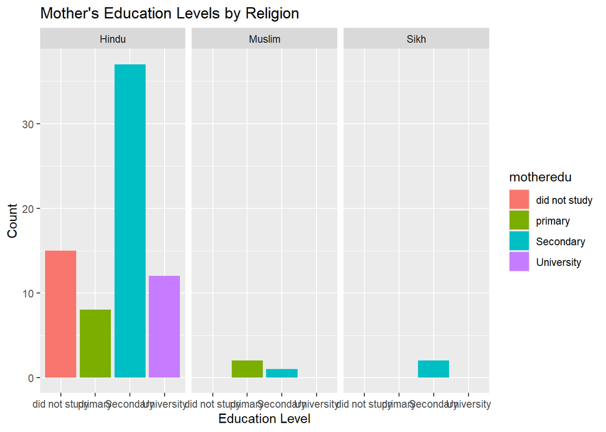

```r
> # Turn motheredu as a factor
> data$motheredu <- as.factor(data$motheredu)
>
> #c Creating a ggplot based on motheredu separated by religion
> data %>%
+   count(religion, motheredu) %>%
+   ggplot(aes(x = motheredu, y = n, fill = motheredu)) +
+   geom_bar(stat = "identity") +
+   facet_wrap(~ religion) +
+   labs(
+     title = "Mother's Education Levels by Religion",
+     x = "Education Level",
+     y = "Count"
+   )
```

This bar plot displays Mother’s Education levels by religion. This sample consists mainly of Hindu mothers who attained secondary education, we can see that the sample size for Muslim mothers and Sikh mothers are very small. This information is important because educational attainment of mothers is often linked to child health outcomes, and religion can influence health-related behaviors such as diet. By understanding the demographics it allow public health professions to target certain groups for interventions or programs to assist the groups. This bar plot also allows us to understand that this data isn’t representative of other religious groups, which is important when making broader conclusions.

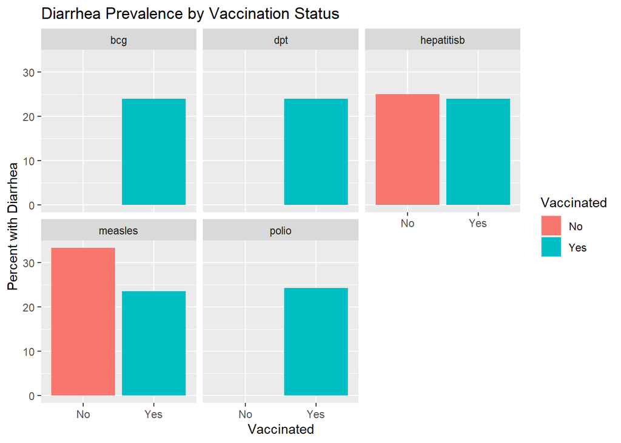

```r
> # Assigning the names of vaccine variables to reference later
> vaccines <- c("bcg", "polio", "dpt", "measles", "hepatitisb")
>
> # converting diarrhea to a factor
> data$diarrhoea <- as.factor(data$diarrhoea)
>
> # Creating a new variable to show diarrhea prevalence
> vaccine_graph <- data %>%
+   select(all_of(vaccines), diarrhoea) %>%
+   pivot_longer(cols = all_of(vaccines), names_to = "Vaccine", values_to = "Vaccinated") %>%
+   filter(!is.na(diarrhoea), !is.na(Vaccinated), Vaccinated %in% c("Yes", "No")) %>%
+   group_by(Vaccine, Vaccinated) %>%
+   summarise(PercentWithDiarrhea = mean(diarrhoea == "Yes") * 100, .groups = "drop")
>
> # Plotting the dataframe made before
> ggplot(vaccine_graph, aes(x = Vaccinated, y = PercentWithDiarrhea, fill = Vaccinated)) +
+   geom_bar(stat = "identity") +
+   facet_wrap(~ Vaccine) +
+   labs(title = "Diarrhea Prevalence by Vaccination Status", x = "Vaccinated", y = "Percent with Diarrhea")
```

### Linear Regression

Linear regression in this study was used to assess predictors of hemoglobin concentration as a continuous outcome. This will allow researchers to evaluate how each variable influences overall hemoglobin levels.

```r
> # Convert sex to factor and set reference level to "female"
> data$sex <- factor(data$sex, levels = c("female", "male"))
>
> # Convert mother's education to a factor in ordinal level
> data$motheredu <- factor(
+   data$motheredu,
+   levels = c("did not study", "Primary", "Secondary", "Higher Secondary", "Graduate and above"),
+   ordered = TRUE
+ )
>
> # List of predictors so I can iterate through them
> predictors_lm <- c(
+   "sex",
+   "childagemo",
+   "motheredu",
+   "wealthindex",
+   "fer_adj",
+   "bodyironcalc_adj",
+   "tfr_adj",
+   "rbp_adj",
+   "zn_adj_aftercorrection",
+   "se_adj",
+   "folate_nmolL",
+   "b12_pmolL",
+   "totalvitd_nmolL",
+   "lncrp_adj"
+ )
>
> # Initialize a data frame to store the data
> df <- data.frame()
>
> # For loop to iterate through the predictors
> for (var in predictors_lm) {
+
+   # Unstandardized linear regression
+   lm_model <- lm(as.formula(paste("hb_gdL ~", var)), data = data)
+
+   # Extract stats
+   coef_raw <- summary(lm_model)$coefficients[2]
+   ci <- confint(lm_model)[2, ]
+   pval <- summary(lm_model)$coefficients[2, 4]
+
+   # Initialize std coef and CI to store
+   coef_std <- NA
+   std_ci <- c(NA, NA)
+
+   # If else statement to determine whether the variable is numeric or categorical
+   # Determine whether variable is numeric for standardization
+   if (is.numeric(data[[var]])) {
+
+     # Standardize the predictor and outcome
+     x_std <- scale(data[[var]])
+     y_std <- scale(data$hb_gdL)
+
+     # Fit to linear regression
+     model_std <- lm(y_std ~ x_std)
+
+     # Extract standardized coef and ci
+     coef_std <- summary(model_std)$coefficients[2,1]
+     std_ci <- confint(model_std)[2, ]
+     } else {
+       coef_std <- NA
+     }
+
+   # Store in results
+   df <- rbind(df, data.frame(
+     Predictor = var,
+     B_Coefficient = round(coef_raw, 2),
+     CI_Lower = round(ci[1], 2),
+     CI_Upper = round(ci[2], 2),
+     Std_Coefficient = round(coef_std, 2),
+     Std_CI_Lower = round(std_ci[1],2),
+     Std_CI_Upper = round(std_ci[2],2),
+     P_Value = round(pval, 2)
+   ))
+ }
>
> # Get rid of the first column that states (2.5%i)
> rownames(df) <- NULL
>
> # Creating a new column that has a more detailed name of the predictor that matches the paper
> df$Predictor <- c(
+   "Sex (male)",
+   "Age (months)",
+   "Maternal education (trend across categories)",
+   "Wealth index (trend across quintiles)",
+   "Adjusted ferritin, μg/L",
+   "Adjusted body iron, mg/kg",
+   "Adjusted sTfR, mg/L",
+   "Adjusted RBP, μmol/L",
+   "Adjusted zinc, μmol/L",
+   "Adjusted selenium, μmol/L",
+   "Folate, nmol/L",
+   "Vitamin B12, pmol/L",
+   "25(OH)D, nmol/L",
+   "Ln-CRP, mg/L"
+ )
>
> # Reorder columns so Predictor is first
> df <- df[, c("Predictor", "B_Coefficient", "CI_Lower", "CI_Upper", "Std_Coefficient", "Std_CI_Lower", "Std_CI_Upper", "P_Value")]
>
> df %>%
+   kbl(caption = "Table 3. Regression Analysis of Sociodemographic and Mirconutrient predictors of Hemoglobin Concentration (g/L) (n=77)") %>%
+   kable_classic(full_width = F, html_font = "Times") %>%
+   column_spec(1, bold = T)
```

Table 3. Regression Analysis of Sociodemographic and Mirconutrient predictors of Hemoglobin Concentration (g/L) (n=77)

| Predictor | B_Coefficient | CI_Lower | CI_Upper | Std_Coefficient | Std_CI_Lower | Std_CI_Upper | P_Value |
| --- | --- | --- | --- | --- | --- | --- | --- |
| Sex (male) | -0.25 | -0.88 | 0.38 | NA | NA | NA | 0.44 |
| Age (months) | -0.05 | -0.14 | 0.04 | -0.13 | -0.36 | 0.10 | 0.26 |
| Maternal education (trend across categories) | -0.10 | -0.60 | 0.41 | NA | NA | NA | 0.71 |
| Wealth index (trend across quintiles) | 0.00 | -0.13 | 0.14 | 0.01 | -0.22 | 0.24 | 0.95 |
| Adjusted ferritin, μg/L | 0.09 | 0.06 | 0.12 | 0.55 | 0.35 | 0.74 | 0.00 |
| Adjusted body iron, mg/kg | 0.25 | 0.20 | 0.30 | 0.78 | 0.63 | 0.92 | 0.00 |
| Adjusted sTfR, mg/L | -0.13 | -0.15 | -0.11 | -0.82 | -0.95 | -0.69 | 0.00 |
| Adjusted RBP, μmol/L | 1.50 | 0.44 | 2.55 | 0.31 | 0.09 | 0.54 | 0.01 |
| Adjusted zinc, μmol/L | 0.05 | -0.13 | 0.24 | 0.07 | -0.17 | 0.31 | 0.58 |
| Adjusted selenium, μmol/L | 0.08 | -0.66 | 0.81 | 0.02 | -0.21 | 0.26 | 0.84 |
| Folate, nmol/L | 0.04 | -0.01 | 0.10 | 0.17 | -0.06 | 0.40 | 0.14 |
| Vitamin B12, pmol/L | 0.00 | 0.00 | 0.00 | -0.10 | -0.33 | 0.13 | 0.38 |
| 25(OH)D, nmol/L | 0.03 | 0.01 | 0.04 | 0.38 | 0.17 | 0.60 | 0.00 |
| Ln-CRP, mg/L | -0.12 | -0.32 | 0.08 | -0.14 | -0.37 | 0.09 | 0.24 |

#### Test for normality

The paper did not perform any tests for normality based on the residuals of each linear regression to assess the assumption of normality.

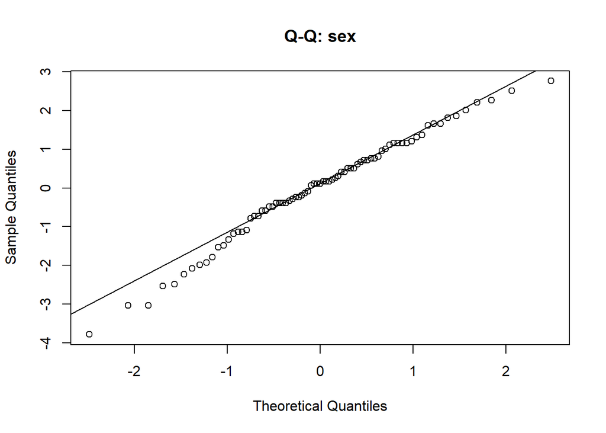

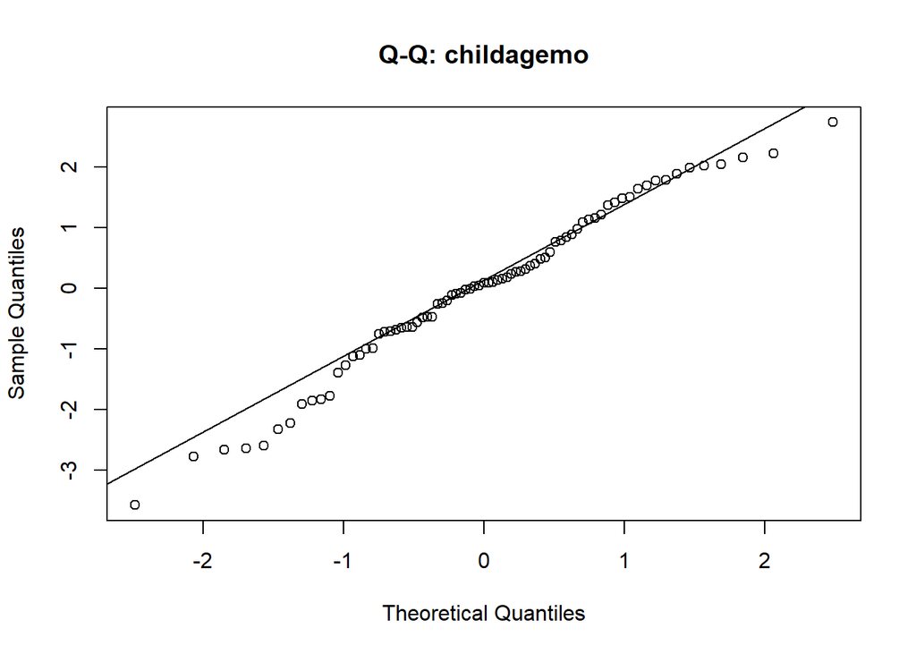

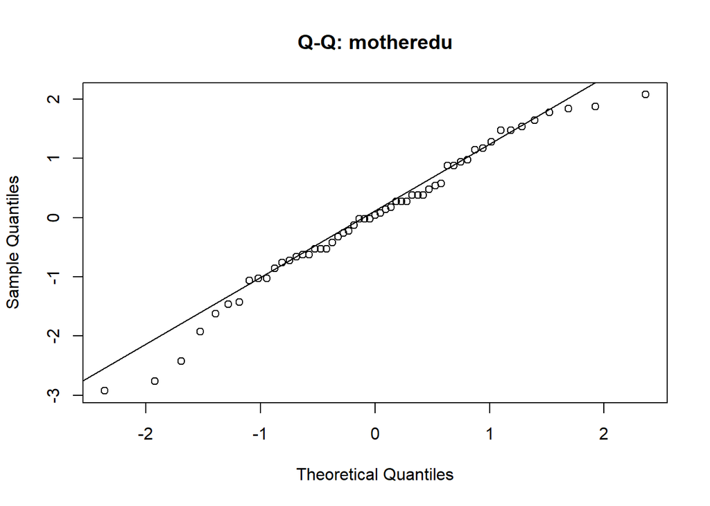

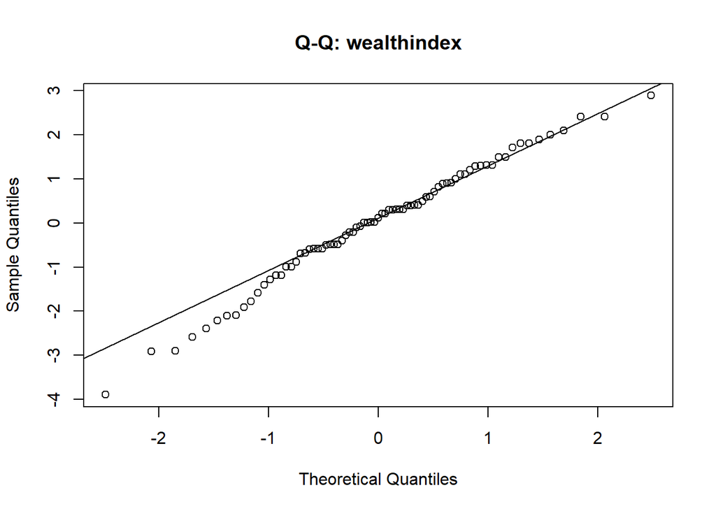

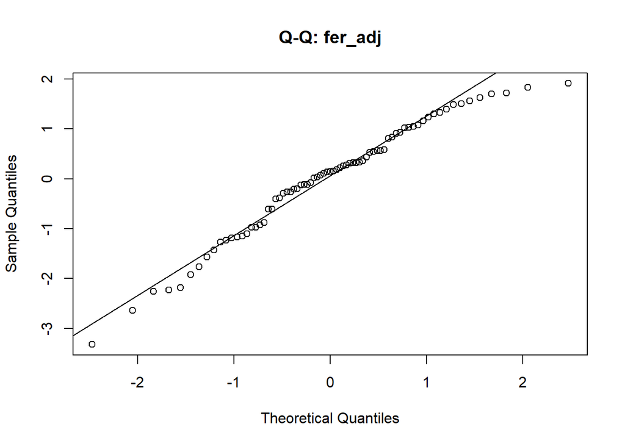

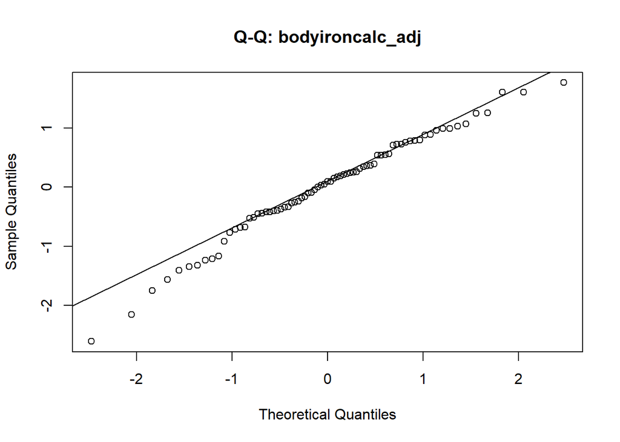

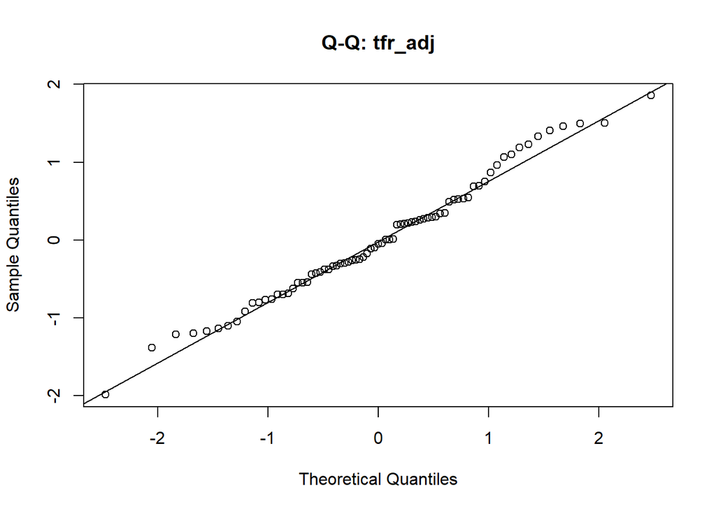

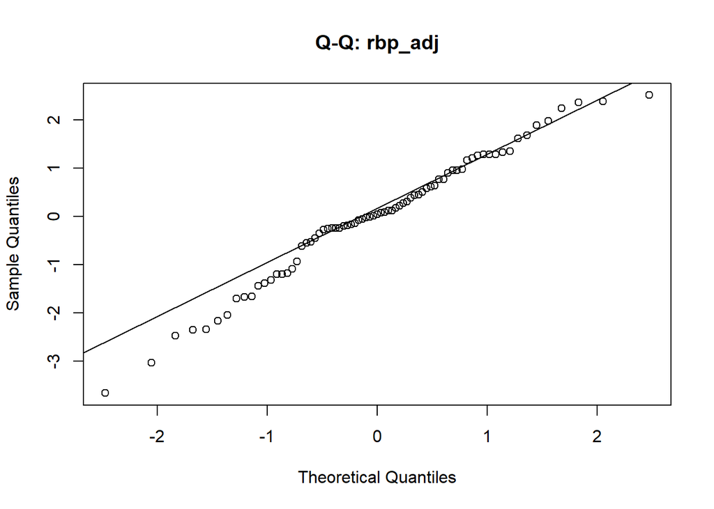

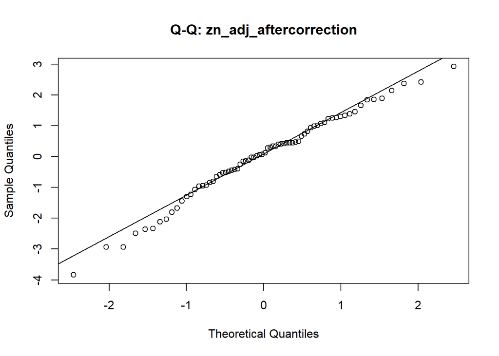

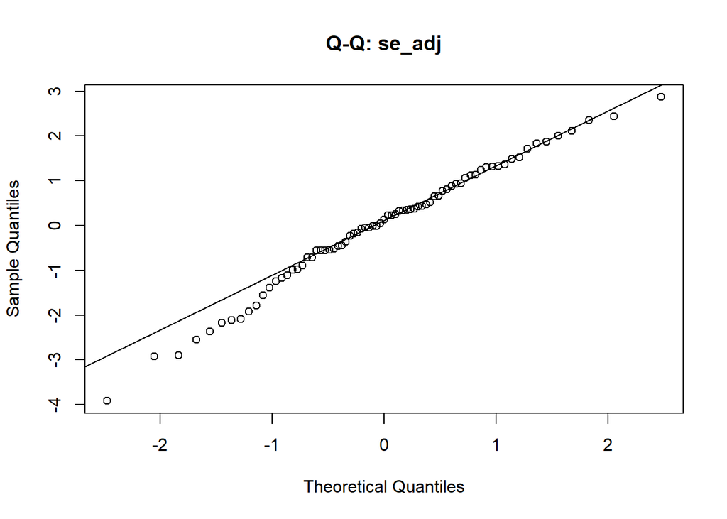

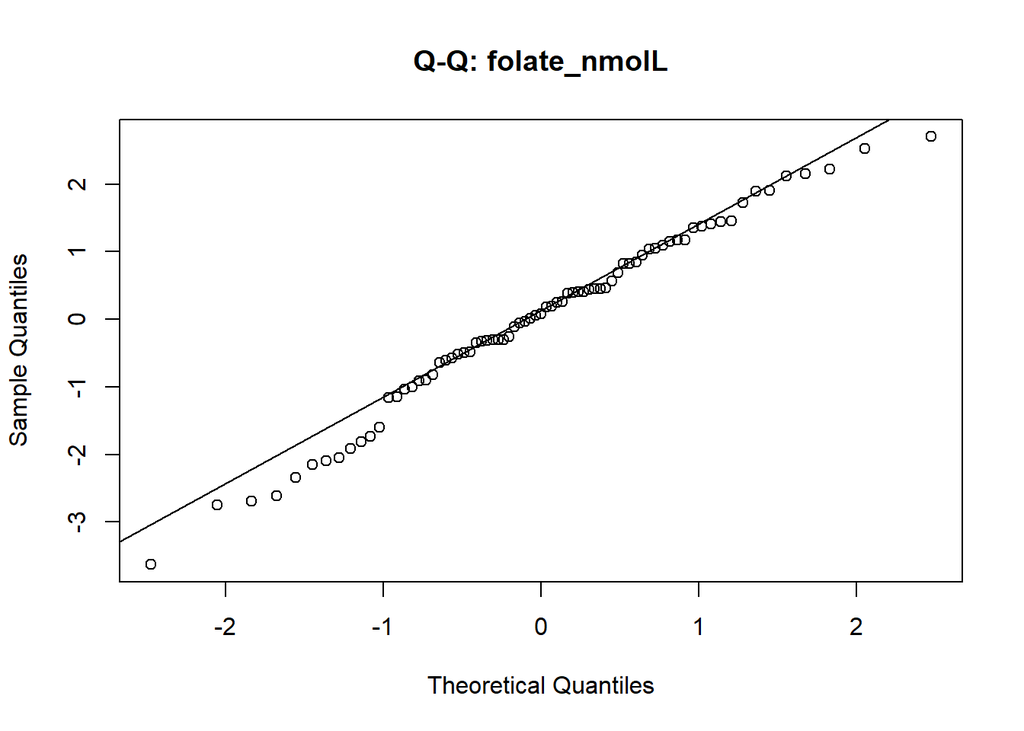

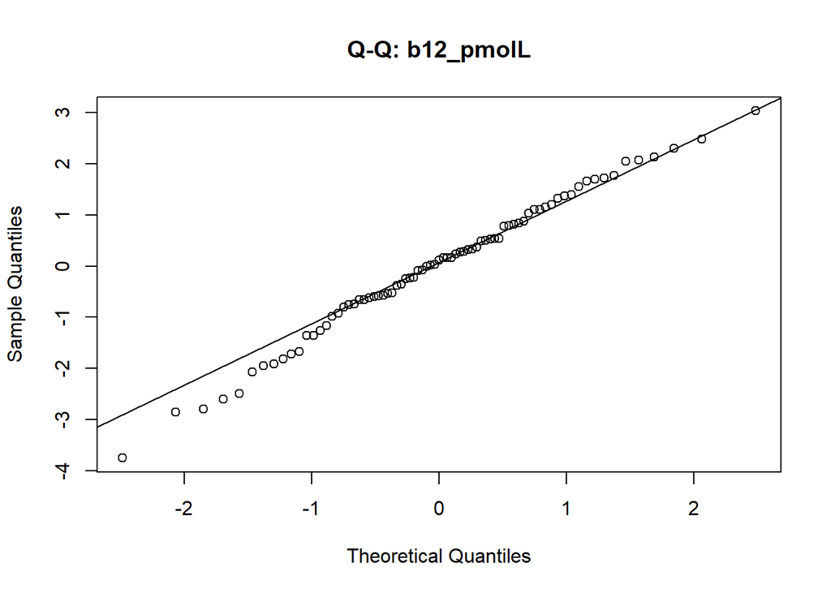

[2 more figures not shown]

```r
> # Iterate through each predictor to create Q-Q plots
> for (var in predictors_lm) {
+   # Fit linear model
+   formula_raw <- as.formula(paste("hb_gdL ~", var))
+   model_raw <- lm(formula_raw, data = data)
+
+   # Generate Q-Q plot for residuals
+   qqnorm(resid(model_raw), main = paste("Q-Q:", var))
+   qqline(resid(model_raw))
+ }
```